# Sick dataset analysis

Michal Stawikowski

04 04 2020

# 1 EDA

```r
print(dfSummary(dataset_raw), method = "render")
```

Data Frame Summary

dataset_raw

**Dimensions**: 3772 x 30  
**Duplicates**: 61

| **No** | **Variable** | **Stats / Values** | **Freqs (% of Valid)** | **Graph** | **Valid** | **Missing** |
| --- | --- | --- | --- | --- | --- | --- |
| 1 | age [numeric] | Mean (sd) : 51.7 (20.1) min < med < max: 1 < 54 < 455 IQR (CV) : 31 (0.4) | 93 distinct values |  | 3771 (99.97%) | 1 (0.03%) |
| 2 | sex [factor] | 1. F 2. M | 2480 ( 68.5% ) 1142 ( 31.5% ) |  | 3622 (96.02%) | 150 (3.98%) |
| 3 | on_thyroxine [factor] | 1. f 2. t | 3308 ( 87.7% ) 464 ( 12.3% ) |  | 3772 (100%) | 0 (0%) |
| 4 | query_on_thyroxine [factor] | 1. f 2. t | 3722 ( 98.7% ) 50 ( 1.3% ) |  | 3772 (100%) | 0 (0%) |
| 5 | on_antithyroid_medication [factor] | 1. f 2. t | 3729 ( 98.9% ) 43 ( 1.1% ) |  | 3772 (100%) | 0 (0%) |
| 6 | sick [factor] | 1. f 2. t | 3625 ( 96.1% ) 147 ( 3.9% ) |  | 3772 (100%) | 0 (0%) |
| 7 | pregnant [factor] | 1. f 2. t | 3719 ( 98.6% ) 53 ( 1.4% ) |  | 3772 (100%) | 0 (0%) |
| 8 | thyroid_surgery [factor] | 1. f 2. t | 3719 ( 98.6% ) 53 ( 1.4% ) |  | 3772 (100%) | 0 (0%) |
| 9 | I131_treatment [factor] | 1. f 2. t | 3713 ( 98.4% ) 59 ( 1.6% ) |  | 3772 (100%) | 0 (0%) |
| 10 | query_hypothyroid [factor] | 1. f 2. t | 3538 ( 93.8% ) 234 ( 6.2% ) |  | 3772 (100%) | 0 (0%) |
| 11 | query_hyperthyroid [factor] | 1. f 2. t | 3535 ( 93.7% ) 237 ( 6.3% ) |  | 3772 (100%) | 0 (0%) |
| 12 | lithium [factor] | 1. f 2. t | 3754 ( 99.5% ) 18 ( 0.5% ) |  | 3772 (100%) | 0 (0%) |
| 13 | goitre [factor] | 1. f 2. t | 3738 ( 99.1% ) 34 ( 0.9% ) |  | 3772 (100%) | 0 (0%) |
| 14 | tumor [factor] | 1. f 2. t | 3676 ( 97.5% ) 96 ( 2.5% ) |  | 3772 (100%) | 0 (0%) |
| 15 | hypopituitary [factor] | 1. f 2. t | 3771 ( 100.0% ) 1 ( 0.0% ) |  | 3772 (100%) | 0 (0%) |
| 16 | psych [factor] | 1. f 2. t | 3588 ( 95.1% ) 184 ( 4.9% ) |  | 3772 (100%) | 0 (0%) |
| 17 | TSH_measured [factor] | 1. t 2. f | 3403 ( 90.2% ) 369 ( 9.8% ) |  | 3772 (100%) | 0 (0%) |
| 18 | TSH [numeric] | Mean (sd) : 5.1 (24.5) min < med < max: 0 < 1.4 < 530 IQR (CV) : 2.2 (4.8) | 287 distinct values |  | 3403 (90.22%) | 369 (9.78%) |
| 19 | T3_measured [factor] | 1. t 2. f | 3003 ( 79.6% ) 769 ( 20.4% ) |  | 3772 (100%) | 0 (0%) |
| 20 | T3 [numeric] | Mean (sd) : 2 (0.8) min < med < max: 0 < 2 < 10.6 IQR (CV) : 0.8 (0.4) | 69 distinct values |  | 3003 (79.61%) | 769 (20.39%) |
| 21 | TT4_measured [factor] | 1. t 2. f | 3541 ( 93.9% ) 231 ( 6.1% ) |  | 3772 (100%) | 0 (0%) |
| 22 | TT4 [numeric] | Mean (sd) : 108.3 (35.6) min < med < max: 2 < 103 < 430 IQR (CV) : 36 (0.3) | 241 distinct values |  | 3541 (93.88%) | 231 (6.12%) |
| 23 | T4U_measured [factor] | 1. t 2. f | 3385 ( 89.7% ) 387 ( 10.3% ) |  | 3772 (100%) | 0 (0%) |
| 24 | T4U [numeric] | Mean (sd) : 1 (0.2) min < med < max: 0.2 < 1 < 2.3 IQR (CV) : 0.2 (0.2) | 146 distinct values |  | 3385 (89.74%) | 387 (10.26%) |
| 25 | FTI_measured [factor] | 1. t 2. f | 3387 ( 89.8% ) 385 ( 10.2% ) |  | 3772 (100%) | 0 (0%) |
| 26 | FTI [numeric] | Mean (sd) : 110.5 (33.1) min < med < max: 2 < 107 < 395 IQR (CV) : 31 (0.3) | 234 distinct values |  | 3387 (89.79%) | 385 (10.21%) |
| 27 | TBG_measured [factor] | 1. f | 3772 ( 100.0% ) |  | 3772 (100%) | 0 (0%) |
| 28 | TBG [numeric] | All NA's |  |  | 0 (0%) | 3772 (100%) |
| 29 | referral_source [factor] | 1. SVHC 2. other 3. SVI 4. STMW 5. SVHD | 386 ( 10.2% ) 2201 ( 58.4% ) 1034 ( 27.4% ) 112 ( 3.0% ) 39 ( 1.0% ) |  | 3772 (100%) | 0 (0%) |
| 30 | Class [factor] | 1. negative 2. sick | 3541 ( 93.9% ) 231 ( 6.1% ) |  | 3772 (100%) | 0 (0%) |

Generated by summarytools 0.9.6 ([R](https://www.r-project.org/) version 3.6.0)  
2020-04-15

Short summary of data. As we can see there are two variables with only one level and some outliers.

## 1.1 Outliers

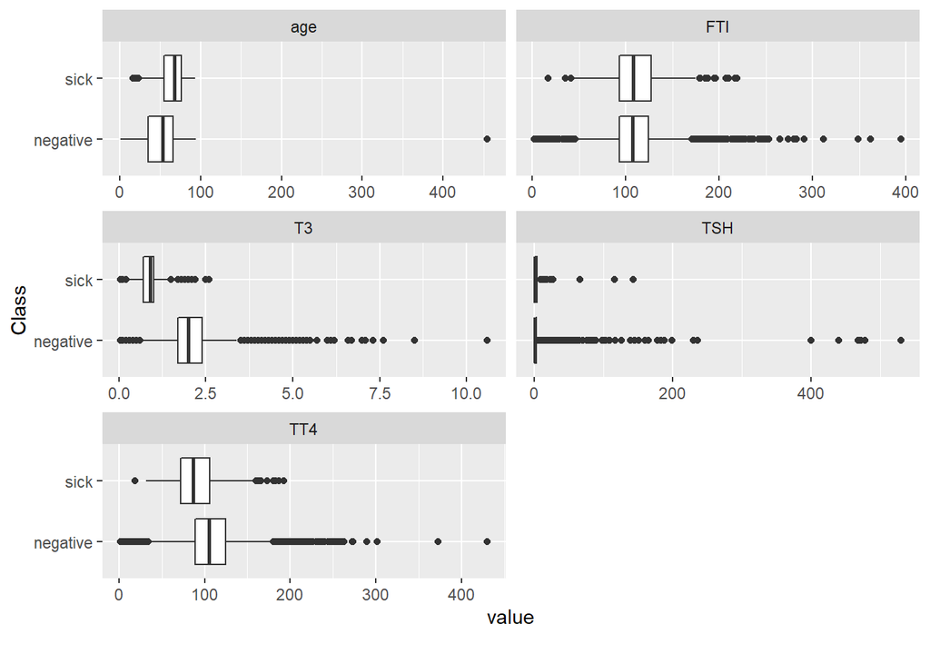

```r
plot_boxplot(dataset_raw[,c("age", "FTI", "TSH", "TT4", "T3", "Class")], by = "Class", ncol = 2)
```

## 1.2 Corelations

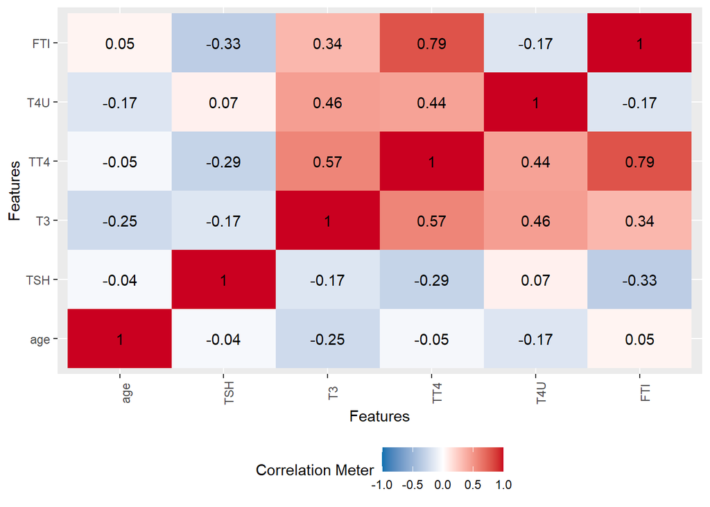

```r
plot_correlation(na.omit(dataset),  type = "c")
```

We can see that some of variables are highly correlated.

## 1.3 PCA

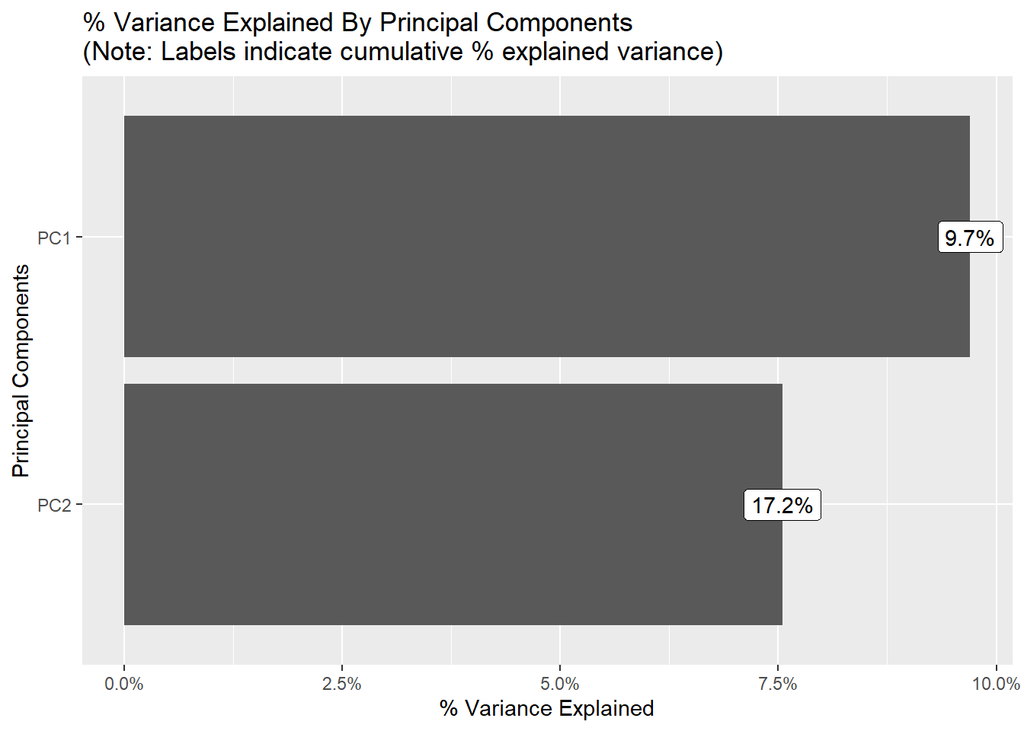

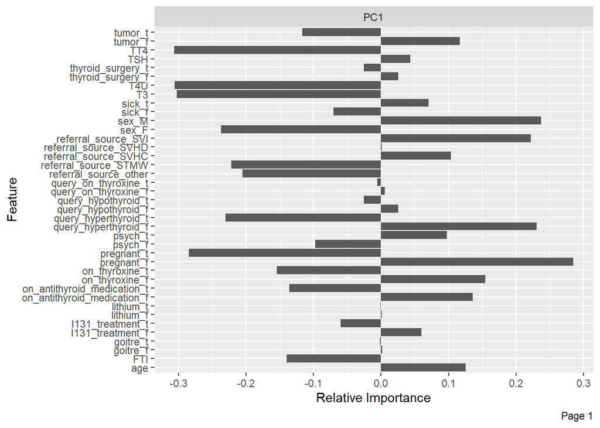

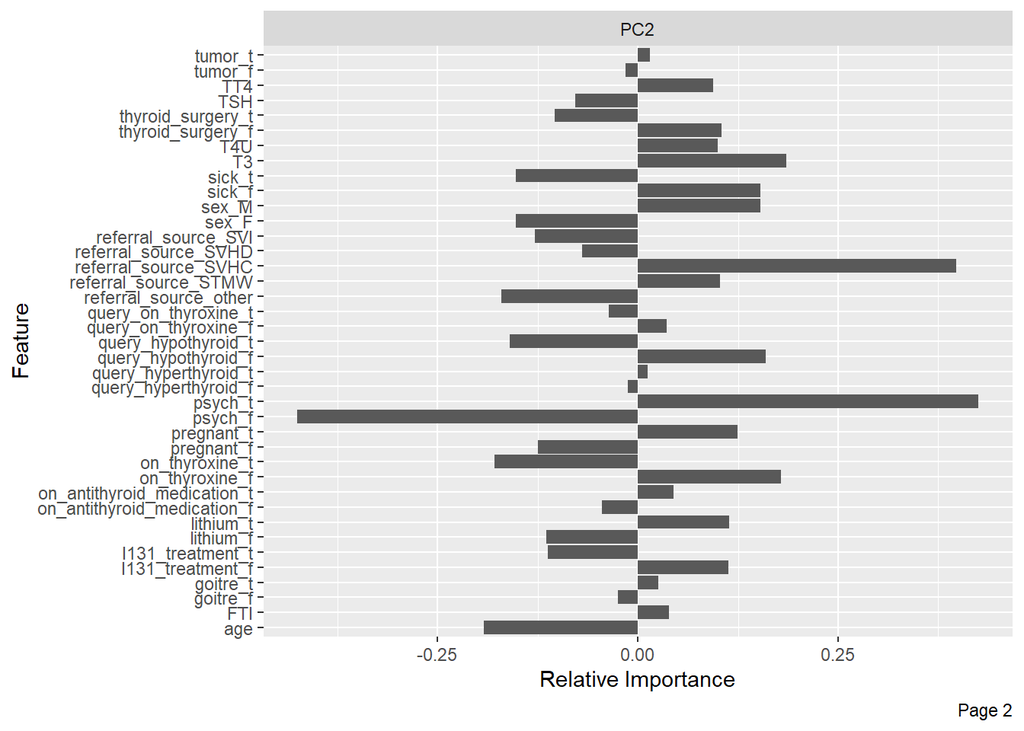

```r
pca_df <- na.omit(select(dataset, -Class))

plot_prcomp(pca_df, variance_cap = 0.23, nrow = 1L, ncol = 1L)
```

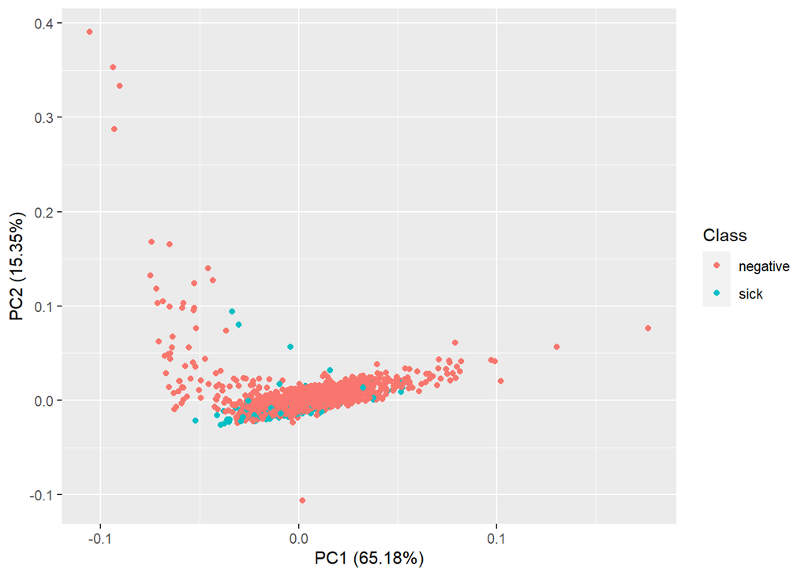

```r
pca_df <- na.omit(dataset)
nums <- unlist(lapply(pca_df, is.numeric))
data <- pca_df[,nums]
autoplot(prcomp(data), data = pca_df, colour = 'Class')
```

PCA did not help a lot with seperating our two classes.

## 1.4 Cross plots

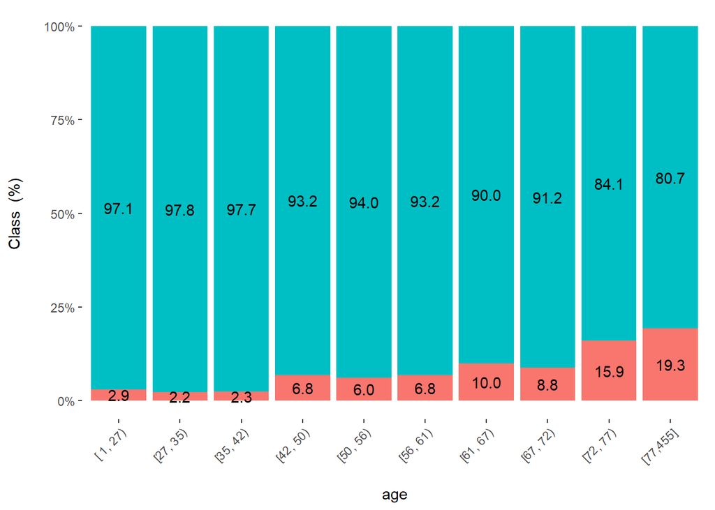

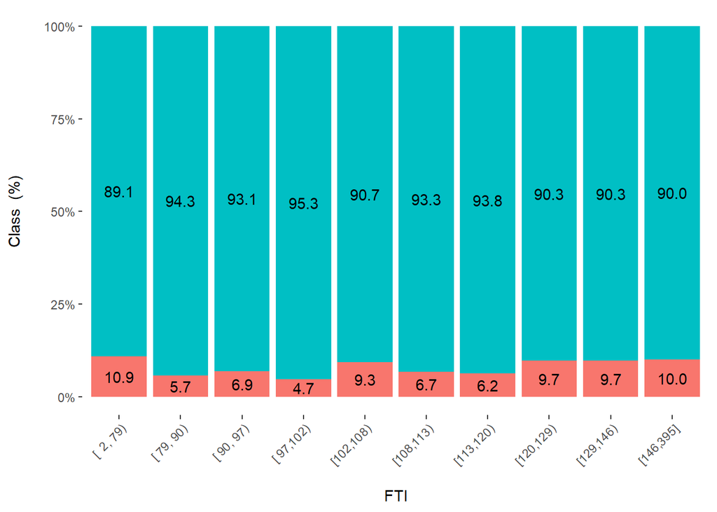

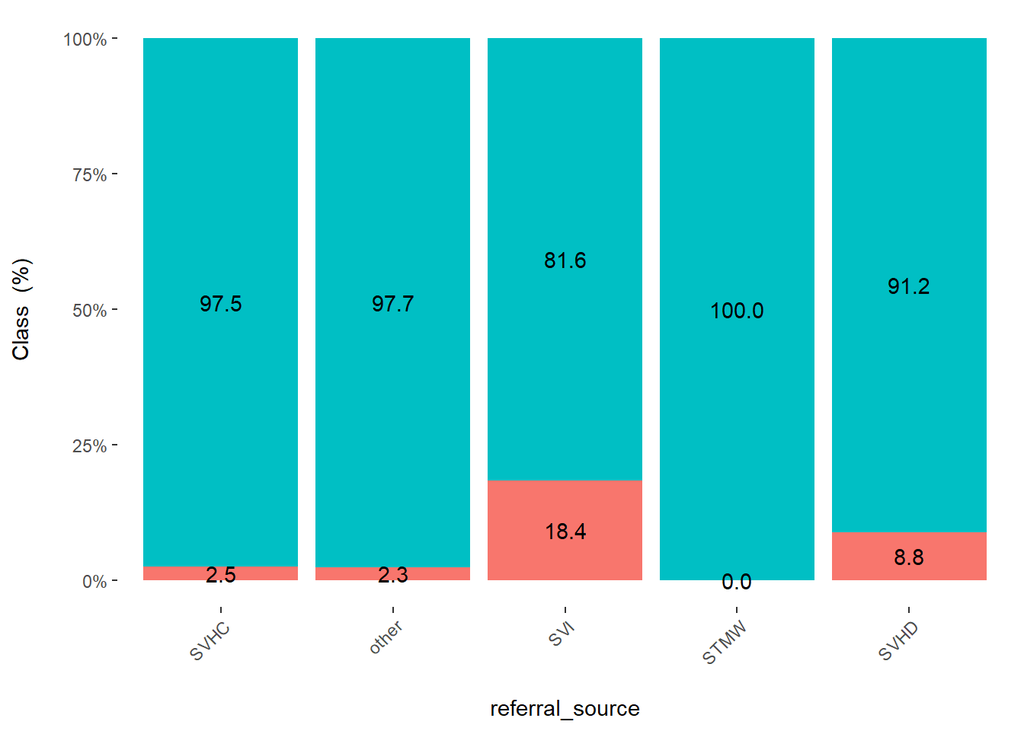

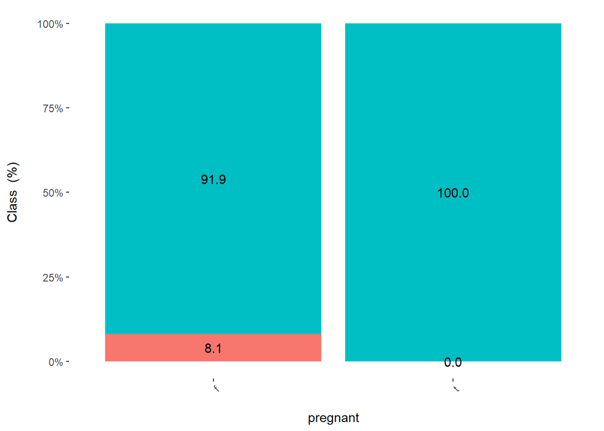

```r
cross_plot(data=na.omit(dataset), input=c("age", "FTI","referral_source", "pregnant"), target="Class", plot_type = "percentual")
```

We can see that age same as referral_source has big impact on our target variable.

# 2 Removing outliers

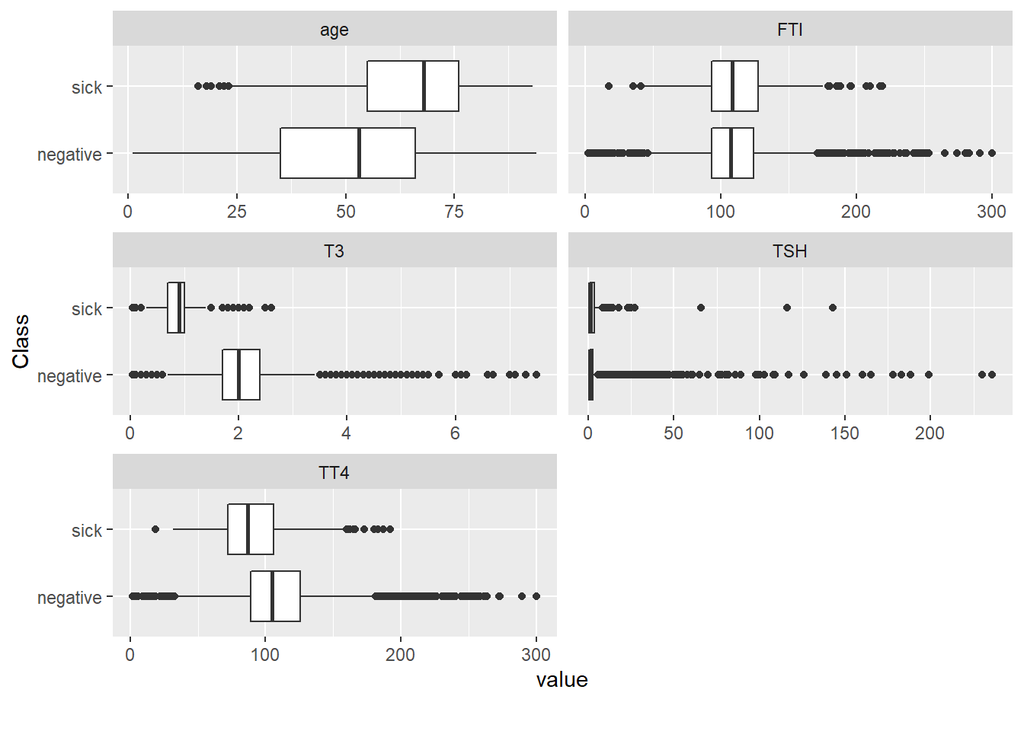

```r
cd <- dataset[dataset$age<120 | is.na(dataset$age),]
cd <- capLargeValues(cd, target = "Class",cols = c("FTI"),threshold = 300)
cd <- capLargeValues(cd, target = "Class",cols = c("T3"),threshold = 7.5)
cd <- cd[cd$TSH<250 | is.na(cd$TSH),]
cd <- capLargeValues(cd, target = "Class",cols = c("TT4"),threshold = 300)

dataset <- cd
plot_boxplot(dataset[,c("age", "FTI", "TSH", "TT4", "T3", "Class")], by = "Class", ncol = 2)
```

We removed the most outliers.

# 3 Imputation

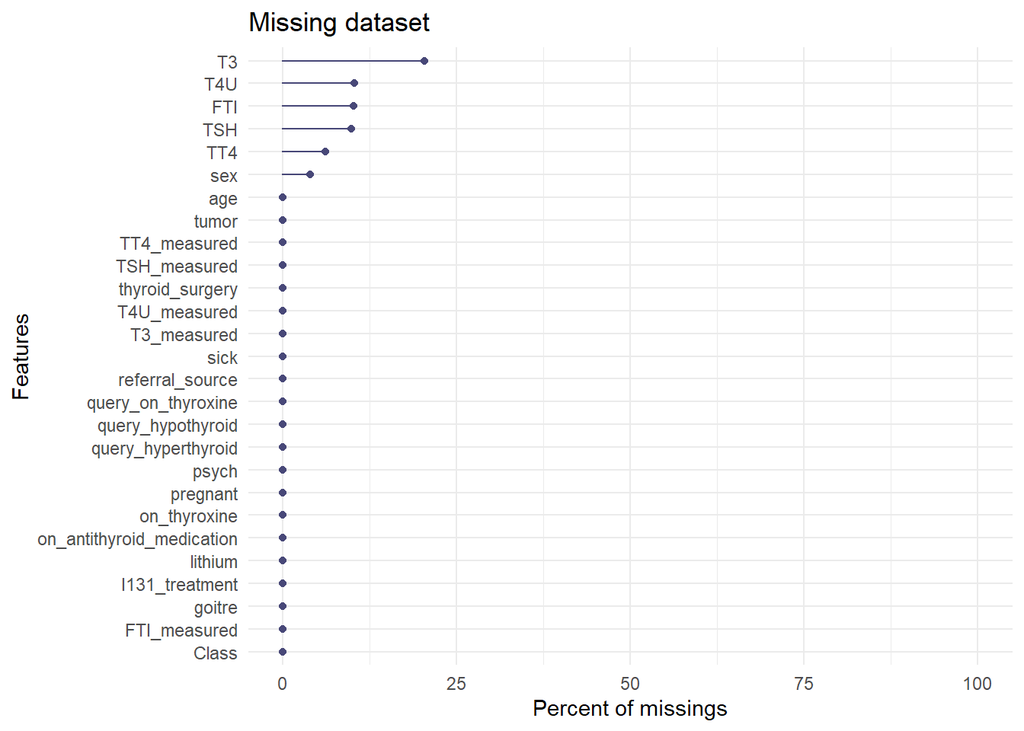

```r
gg_miss_var(dataset,
            show_pct = TRUE) +
  ylim(0, 100) +
  labs(title = "Missing dataset",
       x = "Features",
       y = "Percent of missings")
```

## 3.1 Pattern of missing data

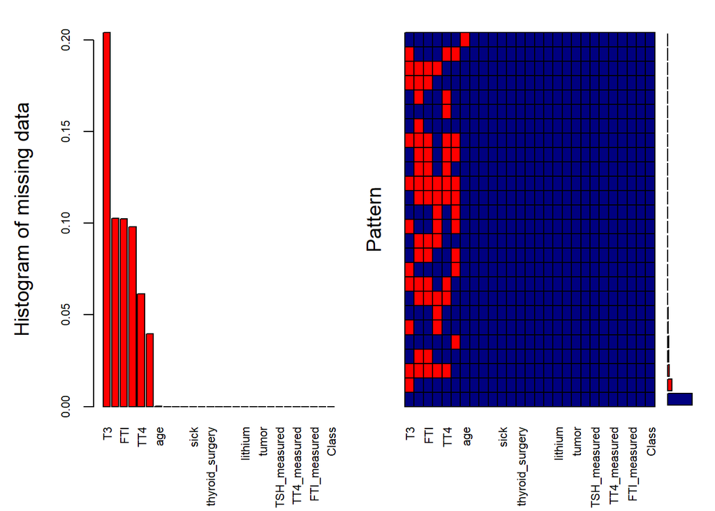

```
##
##  Variables sorted by number of missings:
##                   Variable        Count
##                         T3 0.2039840637
##                        T4U 0.1027888446
##                        FTI 0.1022576361
##                        TSH 0.0980079681
##                        TT4 0.0613545817
##                        sex 0.0395750332
##                        age 0.0002656042
##               on_thyroxine 0.0000000000
##         query_on_thyroxine 0.0000000000
##  on_antithyroid_medication 0.0000000000
##                       sick 0.0000000000
##                   pregnant 0.0000000000
##            thyroid_surgery 0.0000000000
##             I131_treatment 0.0000000000
##          query_hypothyroid 0.0000000000
##         query_hyperthyroid 0.0000000000
##                    lithium 0.0000000000
##                     goitre 0.0000000000
##                      tumor 0.0000000000
##                      psych 0.0000000000
##               TSH_measured 0.0000000000
##                T3_measured 0.0000000000
##               TT4_measured 0.0000000000
##               T4U_measured 0.0000000000
##               FTI_measured 0.0000000000
##            referral_source 0.0000000000
##                      Class 0.0000000000
```

```r
aggr_plot <- aggr(dataset, col=c('navyblue','red'), numbers=TRUE, sortVars=TRUE, labels=names(dataset), cex.axis=.7, gap=3, ylab=c("Histogram of missing data","Pattern"))
```

From above plot we can see that most of data is ok, and the missing ones are likely to be random.

We will test various forms of imputation and choose the best using a model resistant to missing data - rpart decision tree.

## 3.2 Mode, mean imputation

```r
imp_basic_train <- mlr::impute(train, classes = list(factor = imputeMode(), numeric = imputeMean()), dummy.classes = c("integer","factor"), dummy.type = "numeric")$data
imp_basic_test <- mlr::impute(test, classes = list(factor = imputeMode(), numeric = imputeMean()), dummy.classes = c("integer","factor"), dummy.type = "numeric")$data
```

## 3.3 Knn imputation

```r
imp_knn_train <- VIM::kNN(train, imp_var = F)
imp_knn_test <- VIM::kNN(test, imp_var = F)
```

## 3.4 Mice imputation

```r
imp_mice_train_F = mice(train, m=5, maxit = 40, print = FALSE)
imp_mice_test_F = mice(test, m=5, maxit = 40, print = FALSE)
imp_mice_train_F$method
```

```
##                       age                       sex
##                        ""                  "logreg"
##              on_thyroxine        query_on_thyroxine
##                        ""                        ""
## on_antithyroid_medication                      sick
##                        ""                        ""
##                  pregnant           thyroid_surgery
##                        ""                        ""
##            I131_treatment         query_hypothyroid
##                        ""                        ""
##        query_hyperthyroid                   lithium
##                        ""                        ""
##                    goitre                     tumor
##                        ""                        ""
##                     psych              TSH_measured
##                        ""                        ""
##                       TSH               T3_measured
##                     "pmm"                        ""
##                        T3              TT4_measured
##                     "pmm"                        ""
##                       TT4              T4U_measured
##                     "pmm"                        ""
##                       T4U              FTI_measured
##                     "pmm"                        ""
##                       FTI           referral_source
##                     "pmm"                        ""
##                     Class
##                        ""
```

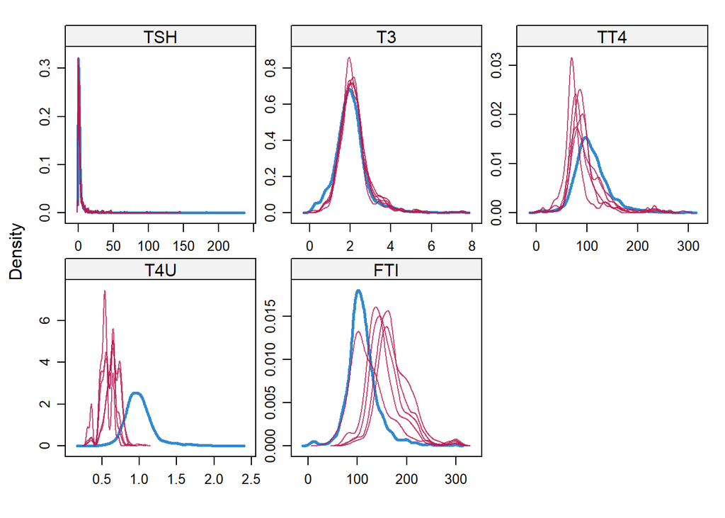

```r
densityplot(imp_mice_train_F)
```

```r
imp_mice_train=mice::complete(imp_mice_train_F,1)
imp_mice_test=mice::complete(imp_mice_test_F,1)
```

On the plot we can see distribution of inputed data - red in comparison to rest of the data - blue. And above this there are methods used to impute.

```r
train_omit <- na.omit(train)
test_omit <- na.omit(test)
```

## 3.5 Comparing with rpart

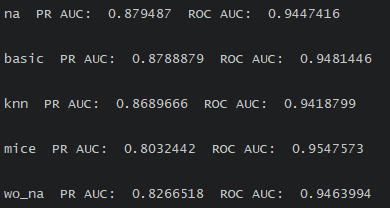

Imputations score

```r
task_na <- mlr::makeClassifTask(id = "na", data = train, target = "Class", positive = 1)
task_basic <- mlr::makeClassifTask(id = "basic", data = imp_basic_train, target = "Class", positive = 1)
task_knn <- mlr::makeClassifTask(id = "knn", data = imp_knn_train, target = "Class", positive = 1)
task_mice <- mlr::makeClassifTask(id = "mice", data = imp_mice_train, target = "Class", positive = 1)
task_wo_na <- mlr::makeClassifTask(id = "wo_na", data = train_omit, target = "Class", positive = 1)

dt <- mlr::makeLearner(cl = "classif.rpart", predict.type = "prob")
rd <- makeResampleDesc("CV", iters=5)
tasks <- list(task_na, task_basic, task_knn, task_mice, task_wo_na)
names <- c("na", "basic", "knn", "mice", "wo_na")



bmr <- benchmark(learners = dt, tasks = tasks, resamplings = rd, measures = auc, show.info = F)
pred <- getBMRPredictions(bmr)

for (name in names) {
truth <- pred[[name]]$classif.rpart$data$truth
probs <- pred[[name]]$classif.rpart$data$prob.1
fg <- probs[truth == 1]
bg <- probs[truth == 0]

pr <- pr.curve(scores.class0 = fg, scores.class1 = bg, curve = T)
roc <- roc.curve(scores.class0 = fg, scores.class1 = bg, curve = T)

cat(name, " PR AUC: ",pr$auc.integral, " ROC AUC: ",roc$auc, "\n")
}
```

The best results in case of PR AUC from the mentioned methods of data imputation were given by the medium and mod method.

# 4 Feature Engineering

## 4.1 Skewness

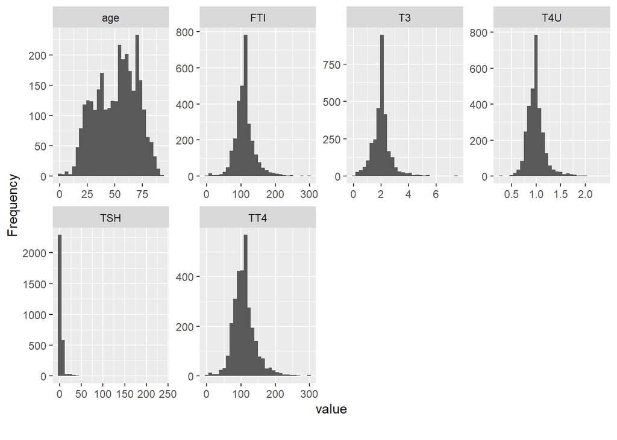

```r
DataExplorer::plot_histogram(imp_basic_train)
```

TSH variable is strongly skewed, we will try to fix it by applying log transformation.

```r
e1071::skewness(imp_basic_train$TSH,type = 2)
```

```
## [1] 9.77135
```

```r
e1071::skewness(imp_basic_train$age,type = 2)
```

```
## [1] -0.2125745
```

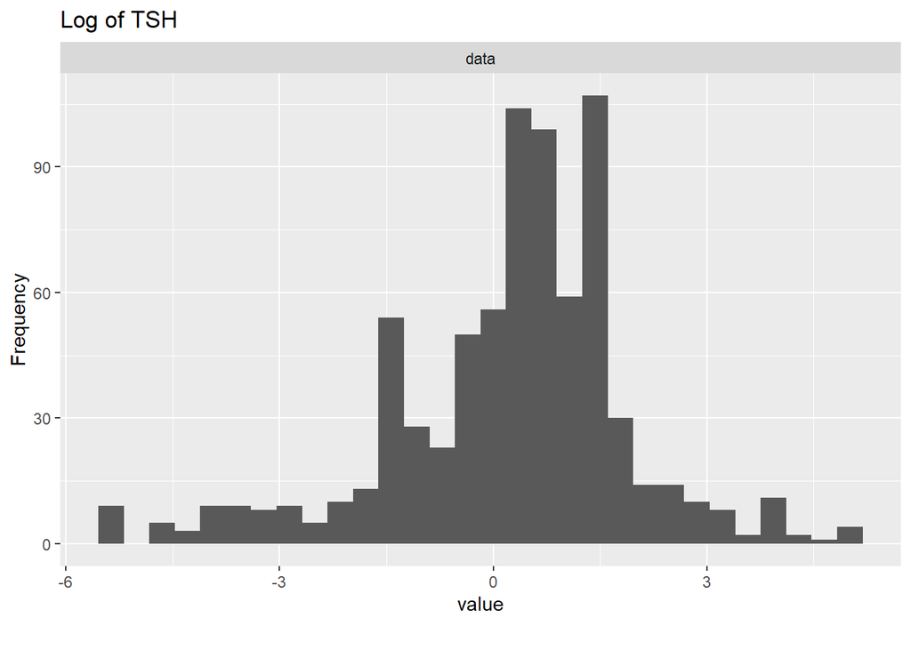

```r
data_tr$TSH <- log(data_tr$TSH)
data_ts$TSH <- log(data_ts$TSH)

plot_histogram(data_ts$TSH, title = "Log of TSH")
```

It looks ok now.

## 4.2 Itepretable models

We will compare some of the interpretable models.

```r
task <- mlr::makeClassifTask(id = "1", data = data_tr, target = "Class", positive = 1)
ctree <- mlr::makeLearner(cl = "classif.rpart", predict.type = "prob")
logreg <- mlr::makeLearner(cl = "classif.logreg", predict.type = "prob")
neigh <- mlr::makeLearner(cl = "classif.kknn", predict.type = "prob")
naive <- mlr::makeLearner(cl = "classif.naiveBayes", predict.type = "prob")

modctree <- mlr::train(ctree, task)
modlog <- mlr::train(logreg, task)
modknn <- mlr::train(neigh, task)
modnaive <- mlr::train(naive, task)

pred_c <- function(model, newdata)  {


  pred <- predict(model, newdata = newdata)
  prob <- getPredictionProbabilities(pred)


  fg <- prob[newdata[,"Class"] == 1]
  bg <- prob[newdata[,"Class"] == 0]

  pr <- pr.curve(scores.class0 = fg, scores.class1 = bg, curve = T)
  return (pr$auc.integral)
}

pred_c2 <- function(data, name)  {


  task <- mlr::makeClassifTask(id = "1", data = data, target = "Class", positive = 1)
  dt <- mlr::makeLearner(cl = paste("classif.", name, sep=""), predict.type = "prob")
  rd <- makeResampleDesc("CV", iters=5)

  bmr <- benchmark(learners = dt, tasks = task, resamplings = rd, measures = auc, show.info = F)
  pred <- getBMRPredictions(bmr)

  arg = paste("classif.", name, sep="")

  truth <- pred$`1`[[arg]]$data$truth
  probs <- pred$`1`[[arg]]$data$prob.1
  fg <- probs[truth == 1]
  bg <- probs[truth == 0]

  pr <- pr.curve(scores.class0 = fg, scores.class1 = bg, curve = T)

  return (pr$auc.integral)
}

pred <-  function(object, newdata) {pred <- predict(object, newdata=newdata)
                                              response <- pred$data[,3]
                                              return(as.numeric(as.character(response)))}

exp_ctree <- DALEX::explain(modctree, data=select(data_ts, -Class), y=as.numeric(as.character(data_ts$Class)), label="tree", predict_function = pred,
                                        colorize = FALSE, verbose = F)
exp_log <- DALEX::explain(modlog, data=select(data_ts, -Class), y=as.numeric(as.character(data_ts$Class)), label="logreg", predict_function = pred,
                                        colorize = FALSE,verbose = F)
exp_knn <- DALEX::explain(modknn, data=select(data_ts, -Class), y=as.numeric(as.character(data_ts$Class)), label="knn", predict_function = pred,
                                        colorize = FALSE,verbose = F)
exp_naive <- DALEX::explain(modnaive, data=select(data_ts, -Class), y=as.numeric(as.character(data_ts$Class)), label="naive", predict_function = pred,
                                        colorize = FALSE,verbose = F)
```

## 4.3 Results

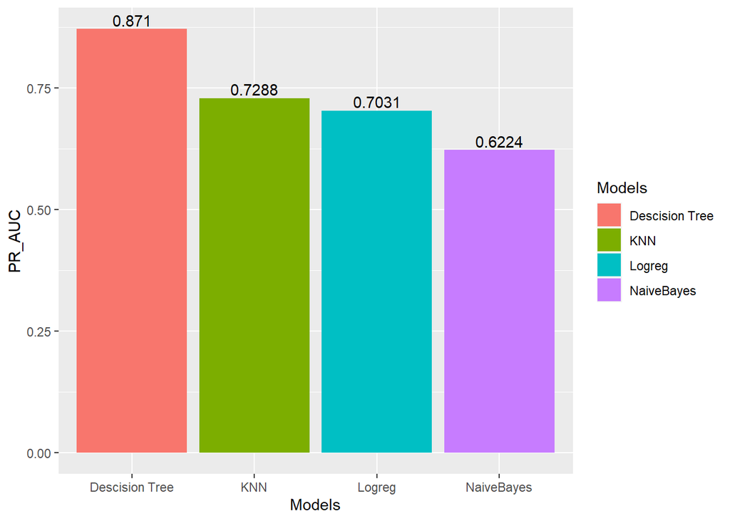

```r
res <- data.frame(PR_AUC = c(pred_c2(data_tr, "rpart"),pred_c2(data_tr, "logreg"),pred_c2(data_tr, "kknn"),pred_c2(data_tr, "naiveBayes")), Models = c("Descision Tree", "Logreg", "KNN", "NaiveBayes"))
ggplot(data = res,aes(x = Models, y = PR_AUC,fill = Models)) + geom_bar(stat = "identity",position = 'dodge') + geom_text(aes(label=sprintf("%0.4f", round(PR_AUC, digits = 4))), position=position_dodge(width=0.9), vjust=-0.25, parse = T)
```

We can see that the decision trees definitely dominated the other models in terms of PR AUC.

## 4.4 XAI

We will compare how models made their decisions.

### 4.4.1 Feature Importance

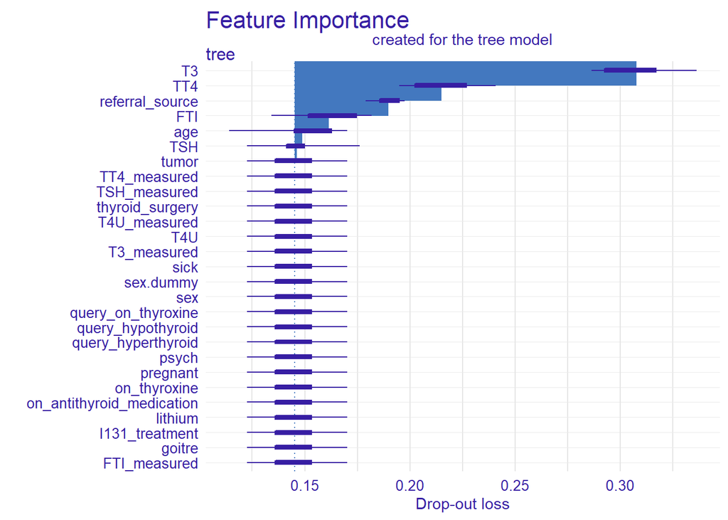

```r
mp_ct <- variable_importance(exp_ctree, loss_function = loss_root_mean_square)
mp_log <- variable_importance(exp_log, loss_function = loss_root_mean_square)
mp_knn<- variable_importance(exp_knn, loss_function = loss_root_mean_square)
plot(mp_ct)
```

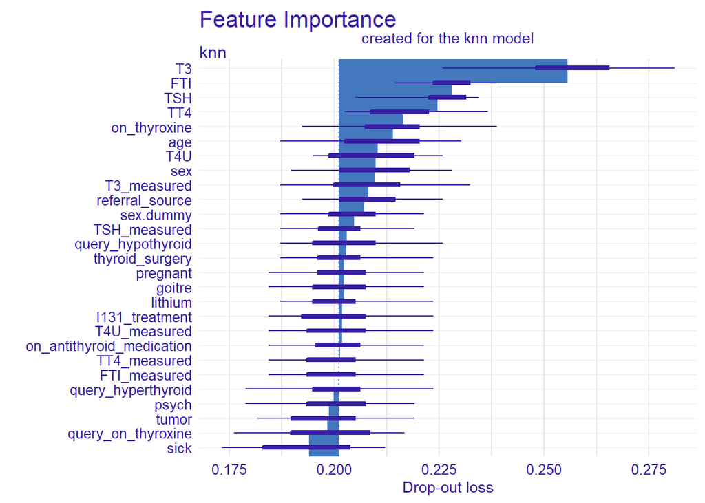

```r
plot(mp_knn)
```

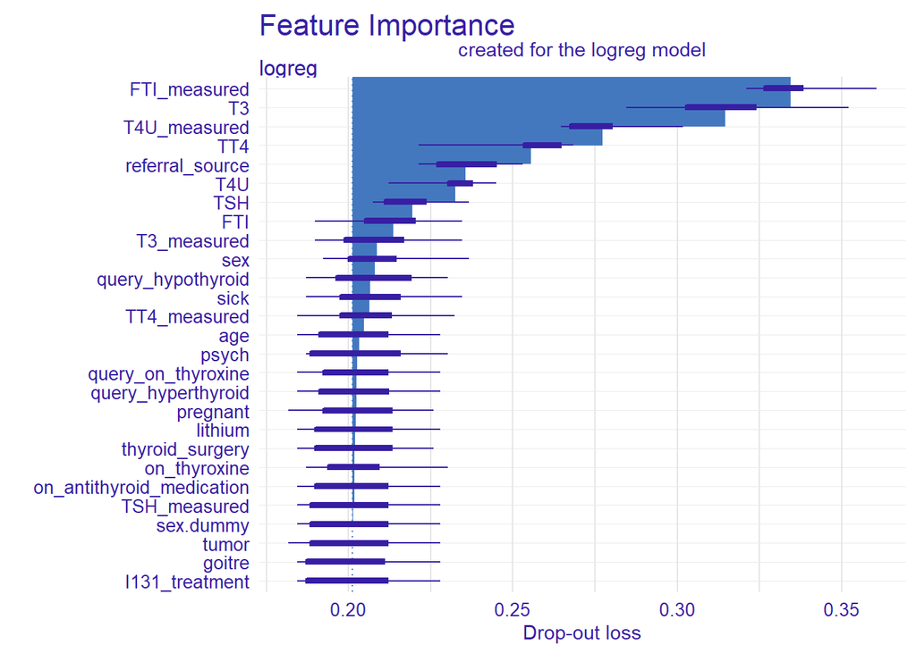

```r
plot(mp_log)
```

Decision trees took into account definitely the least variables.

### 4.4.2 PDP

#### 4.4.2.1 TT4

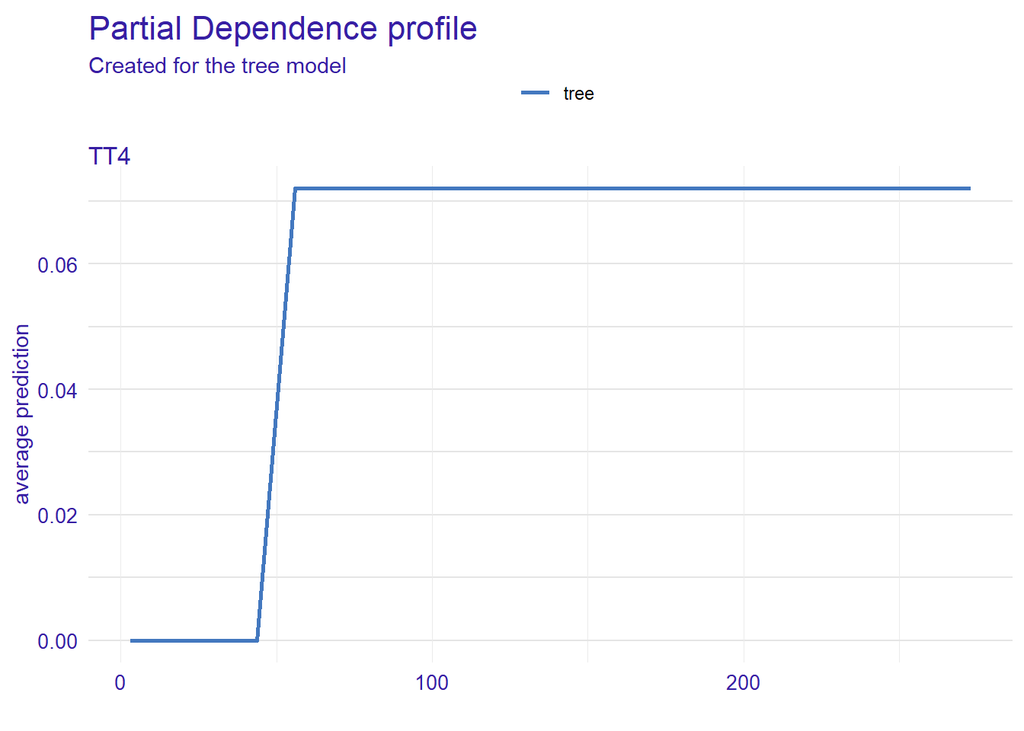

```r
pdp_ct  <- variable_effect(exp_ctree, variable = "TT4", type = 'partial_dependency')
pdp_log  <- variable_effect(exp_log, variable = "TT4", type = 'partial_dependency')
pdp_knn  <- variable_effect(exp_knn, variable = "TT4", type = 'partial_dependency')

plot(pdp_ct)
```

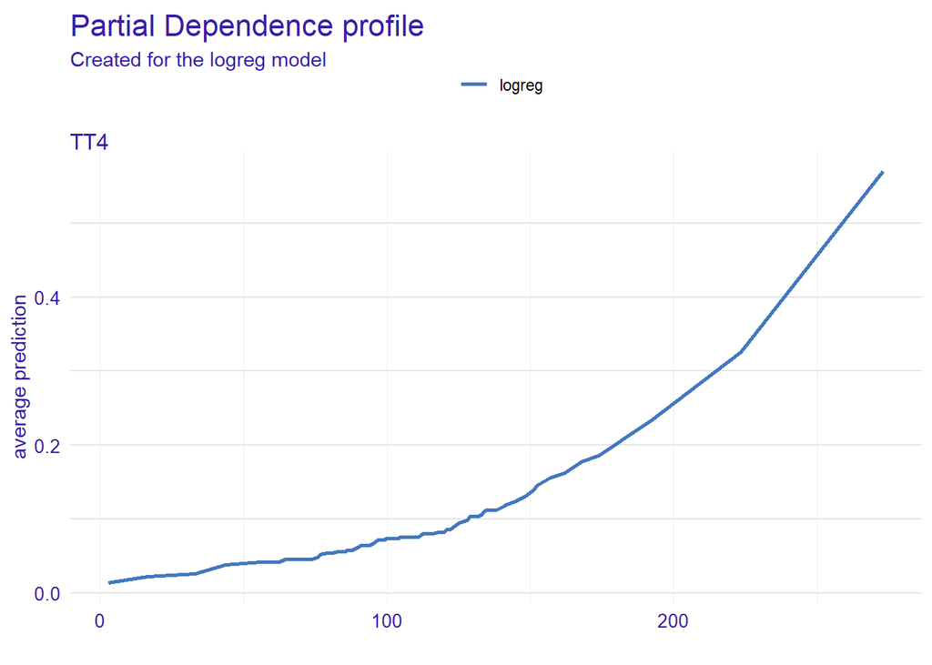

```r
plot(pdp_log)
```

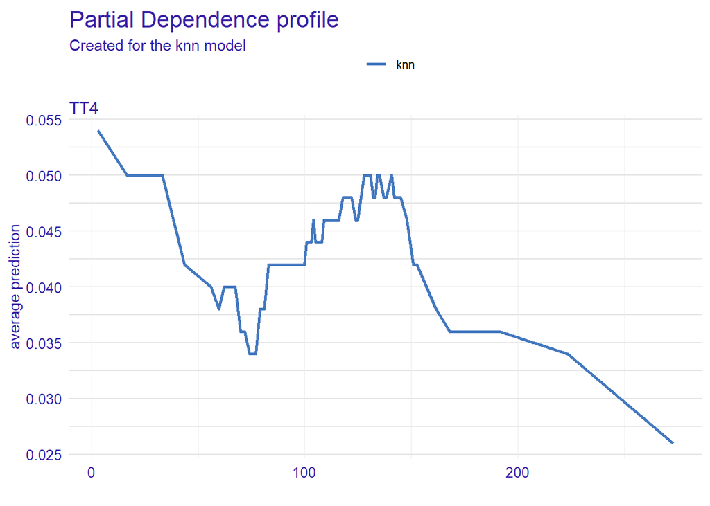

```r
plot(pdp_knn)
```

Compared to other models, rpart simply divided the data relative to the variables considered.

#### 4.4.2.2 FTI

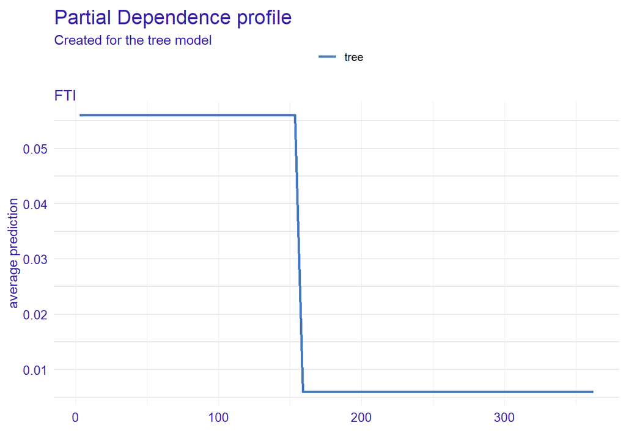

```r
pdp_ct  <- variable_effect(exp_ctree, variable = "FTI", type = 'partial_dependency')
pdp_log  <- variable_effect(exp_log, variable = "FTI", type = 'partial_dependency')
pdp_knn  <- variable_effect(exp_knn, variable = "FTI", type = 'partial_dependency')

plot(pdp_ct)
```

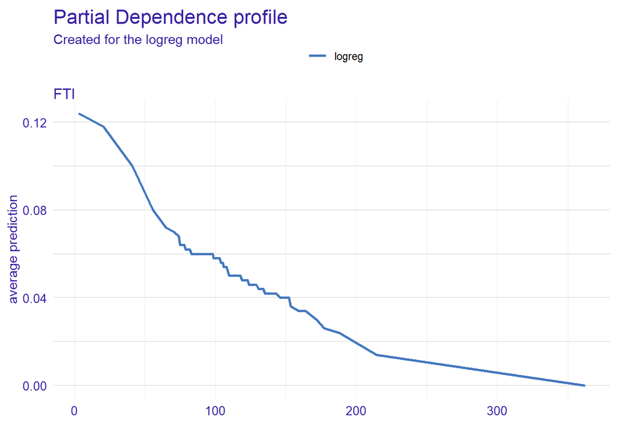

```r
plot(pdp_log)
```

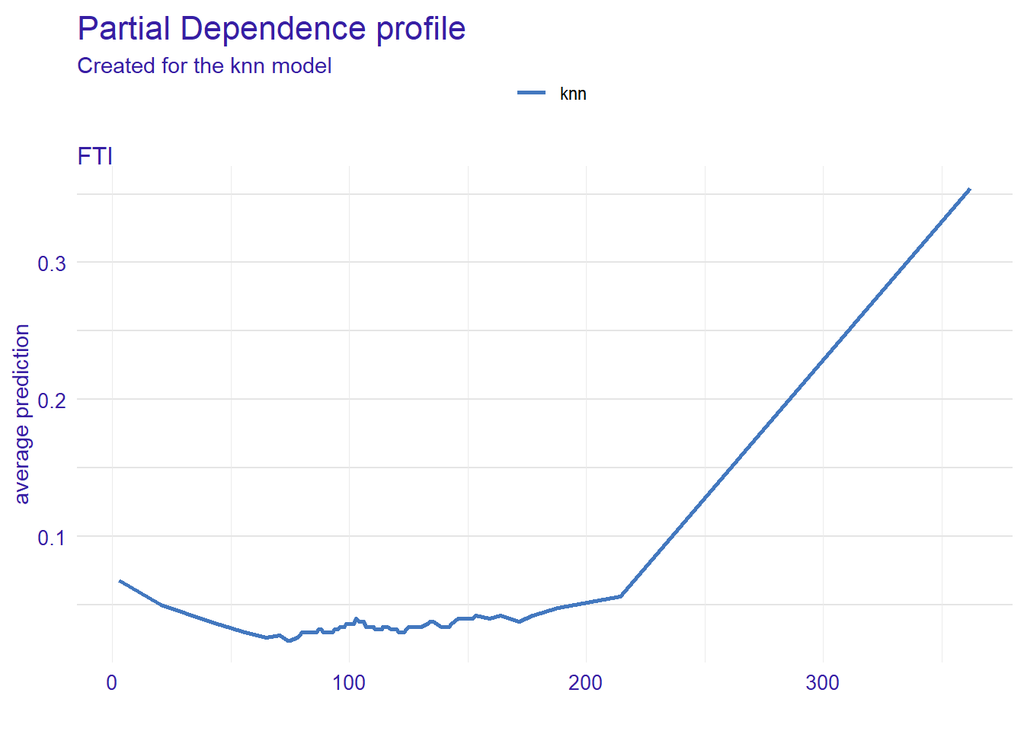

```r
plot(pdp_knn)
```

In the case of rpart, we see a division into only two groups.

#### 4.4.2.3 Referral_source

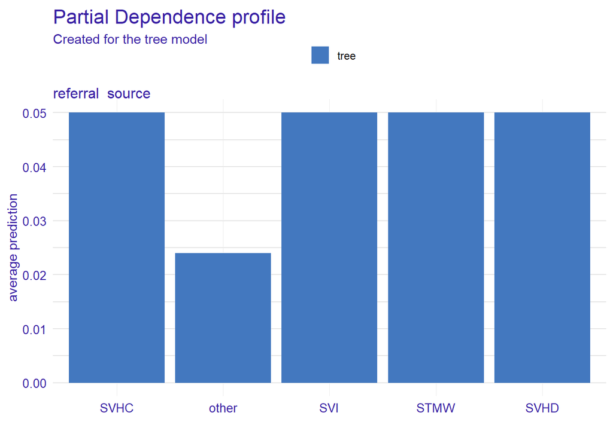

```r
pdp_ct  <- variable_effect(exp_ctree, variable = "referral_source", type = 'partial_dependency')
pdp_log  <- variable_effect(exp_log, variable = "referral_source", type = 'partial_dependency')
pdp_knn  <- variable_effect(exp_knn, variable = "referral_source", type = 'partial_dependency')

plot(pdp_ct)
```

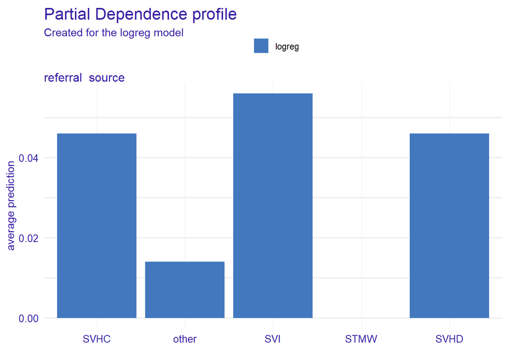

```r
plot(pdp_log)
```

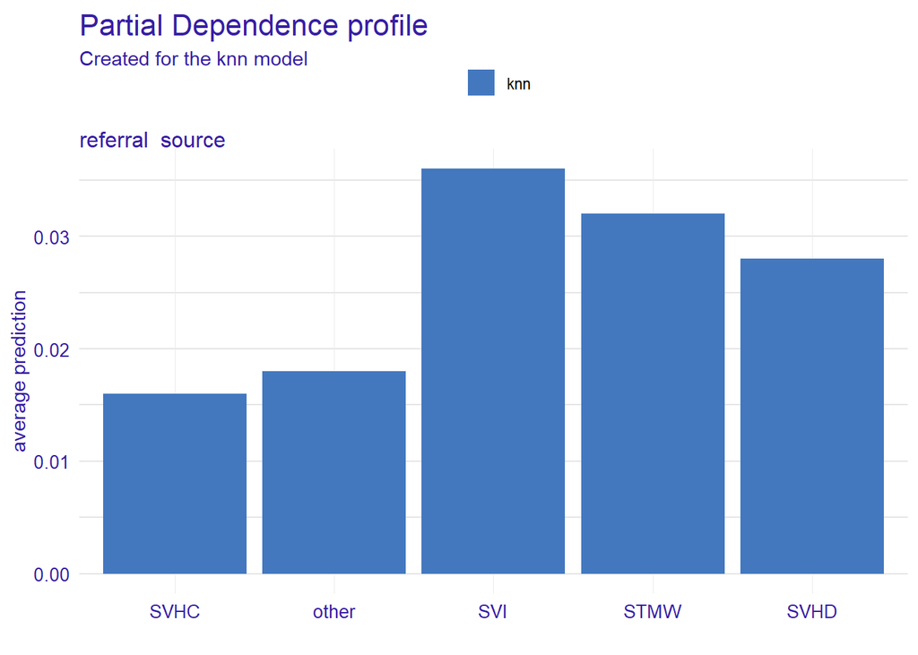

```r
plot(pdp_knn)
```

This time rpart made quite an interesting decision considering the proportions of the sick and healthy, which we saw on crossplots.

## 4.5 Decision tree

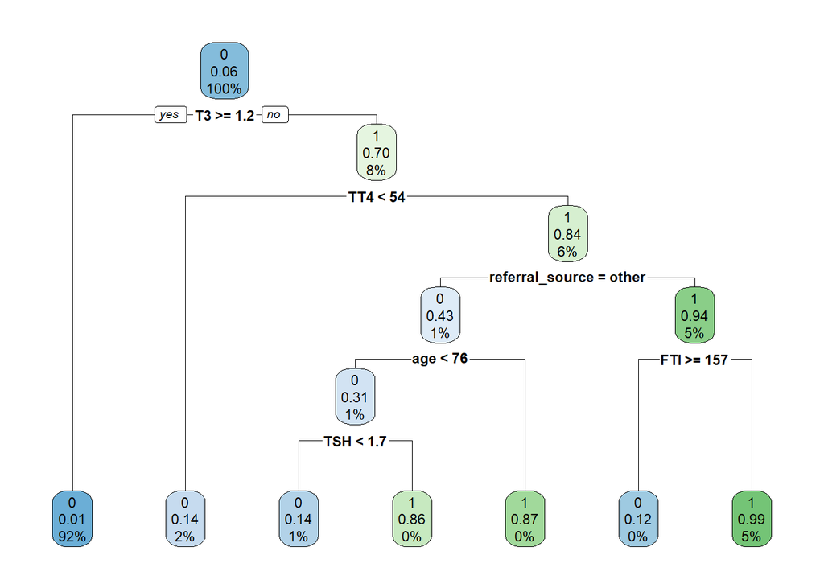

```r
rparttree <- rpart(Class~., data = data_tr, model = T)
rpart.plot::rpart.plot(rparttree)
```

The rpart classification was based only on 6 different variables and still obtained the best results. This could be the key to getting better results. So let’s look at an algorithms, similar to decision trees but definitely more powerful - Random Forest and Xgboost. We will try to use the ways it divides data during the classification.

## 4.6 Black boxes

### 4.6.1 Random Forest

```r
task <- mlr::makeClassifTask(id = "1", data = data_tr, target = "Class", positive = 1)
dt <- mlr::makeLearner(cl = "classif.ranger", predict.type = "prob")
rd <- makeResampleDesc("CV", iters=5)

bmr <- benchmark(learners = dt, tasks = task, resamplings = rd, measures = auc, show.info = F)
pred <- getBMRPredictions(bmr)

truth <- pred$`1`$classif.ranger$data$truth
probs <- pred$`1`$classif.ranger$data$prob.1
fg <- probs[truth == 1]
bg <- probs[truth == 0]

pr <- pr.curve(scores.class0 = fg, scores.class1 = bg, curve = T)
pr$auc.integral
```

```
## [1] 0.9528999
```

```r
roc <- roc.curve(scores.class0 = fg, scores.class1 = bg, curve = T)
roc$auc
```

```
## [1] 0.9944114
```

### 4.6.2 Xgboost

```r
xg <- select(data_tr, -Class)

xg <- one_hot(data.table(xg))
xg$Class = select(data_tr, Class)
xg <- data.frame(xg)

xgt <- select(data_ts, -Class)

xgt <- one_hot(data.table(xgt))
xgt$Class = select(data_ts, Class)
xgt <- data.frame(xgt)

task <- mlr::makeClassifTask(id = "1", data = xg, target = "Class", positive = 1)
dt <- mlr::makeLearner(cl = "classif.xgboost", predict.type = "prob")
rd <- makeResampleDesc("CV", iters=5)

bmr <- benchmark(learners = dt, tasks = task, resamplings = rd, measures = auc, show.info = F)
pred <- getBMRPredictions(bmr)

truth <- pred$`1`$classif.xgboost$data$truth
probs <- pred$`1`$classif.xgboost$data$prob.1
fg <- probs[truth == 1]
bg <- probs[truth == 0]

pr <- pr.curve(scores.class0 = fg, scores.class1 = bg, curve = T)
pr$auc.integral
```

```
## [1] 0.9200412
```

```r
roc <- roc.curve(scores.class0 = fg, scores.class1 = bg, curve = T)
roc$auc
```

```
## [1] 0.9694279
```

Both black-box models obtained very good results on our data set. Let’s try to use them in upgrading our interpretable models.